# Course Final Assignment ‘ToxCast’

Marc Teunis

2017-07-14

# Directions

## Package suggestion, you may need others!

```r
library(tidyverse)
```

*Use ggplot2 syntaxis for all the figures in this assigment study*

*Use packages of the tidyverse, or any other package you think you need to solve the questions below*

*Use this Rmarkdown template to create a report adressing the assignment below*

*Hand in the assignment at or before the deadline: 15 September, 2017*

## Grading

For more information on the grading of the assignment and the review criteria, see the document “grading_documents.html”

## Introduction

For the assessment of potential harmful exffects of chemicals, animal testing is required. Recently, a large study was conducted called “ToxCast”.

## The data

The data can be found in the folder “./assignments/toxcast/”

Remember `rprojroot`?

```r
## defines the root of the project for later use
require("rprojroot") || utils::install.packages("rprojroot")
```

```
## [1] TRUE
```

```r
library(rprojroot)
root <- find_root_file(criterion = is_rstudio_project)
```

The file that you need to read into R is:

```r
data_file <- list.files(file.path(root, "assignments", "toxcast"), pattern = "^toxrefdb*", full.names = TRUE)
```

Once loaded into R the data should have the dimensions 11815, 53, rows by columns.

For more details on the data see: ftp://newftp.epa.gov/comptox/High_Throughput_Screening_Data/Animal_Tox_Data/ The data was downloaded from this website on 11 July 2017

## General TIPS

- Inspect the data
- Look at complete cases
- Remove NAs
- Tidy data if necessary
- Solve overplotting issues by using `alpha` and/or `facet_wrap`
- The Rmd file you write must include all the steps of the analysis, including data load and graphics
- For this case you need to know about importing data in R. The file is csv format, remember to set the `na.strings`. In this dataset NA’s are indicated by the term `NULL` Determine the delimiter used in the datafile.
- Remember the programming rules: use `snake_case` for all variables in the data and in your script.
- Use the syntax from the {tidyverse} as much a possible
- You are allowed to use google/stack overflow, whatever you can find to solve the questions
- All graphics must be made with {ggplot2}
- Remember {dplyr} to `select()`, `filter()`, `group_by()`, `mutate()` and `summarize()` data
- Check the type of each variable in the data. Do you need to change the variable type like `data$var_1 <- as.factor(data$var_1)`?
- All graphs need to have proper titles and axis labelling

## The case assignment

1. Create a github repository “toxcast_assignment” in your account.
2. Read the data into R
3. Inspect the data
4. Describe missing values and the type of variables
5. Generate **at least 4** different graphs that describe the data
6. Describe all the steps you performed to load, clean, tidy, wrangle and visualize the data
7. Explain why you select certain variables or make other selections or changes
8. Answer the case questions below.
9. Upload a rendered (**github_document**) and the associated *.Rmd file (name the files both: “toxcast_assignment”) to your github account with the solutions to the assignment
10. Sent the teacher an email with the link to the files (the repository), before the deadline

# Case questions

Try to answer the next 4 questions with a graph and narratives explaining what can be seen in the graph:

Write a general conclusion on the four graphs you create.

## Graph 1) Plotting two categorical variables, and prevent overplotting.

## 1A) How does the relationship between the chemicals (“chemical_name”) and the “effect_category” variable look?

**TIPS**

- This is a plot with two categorical variables.
- To prevent overplotting, do you need to use `geom_jitter(possition = "jitter")`?
- Remember setting `alpha()`?
- Try using facets.

**ANSWER**

```r
#?sample
names(toxcast)
```

```
##  [1] "X1"                           "chemical_id"
##  [3] "chemical_casrn"               "chemical_name"
##  [5] "chemical_sets"                "data_source"
##  [7] "entry_status_id"              "entry_status"
##  [9] "entry_level_id"               "entry_level"
## [11] "usability"                    "usability_desc"
## [13] "study_id"                     "source_study_numeric_id"
## [15] "source_study_alphanumeric_id" "year"
## [17] "citation"                     "guideline_no"
## [19] "guideline_name"               "study_type_id"
## [21] "species_id"                   "strain"
## [23] "comments_animal"              "admin_method"
## [25] "admin_route"                  "dose_start"
## [27] "dose_start_unit"              "dose_end"
## [29] "dose_end_unit"                "lot_batch"
## [31] "purity"                       "source"
## [33] "ldt"                          "hdt"
## [35] "dose_unit"                    "no_doses_tested"
## [37] "study_type"                   "species"
## [39] "effect_category"              "study_level_lel_dose_level"
## [41] "lel_qualifier"                "lel_dose_level"
## [43] "lel_dose"                     "nel_qualifier"
## [45] "nel_dose_level"               "nel_dose"
## [47] "study_level_loael_dose_level" "loael_qualifier"
## [49] "loael_dose_level"             "loael_dose"
## [51] "noael_qualifier"              "noael_dose_level"
## [53] "noael_dose"
```

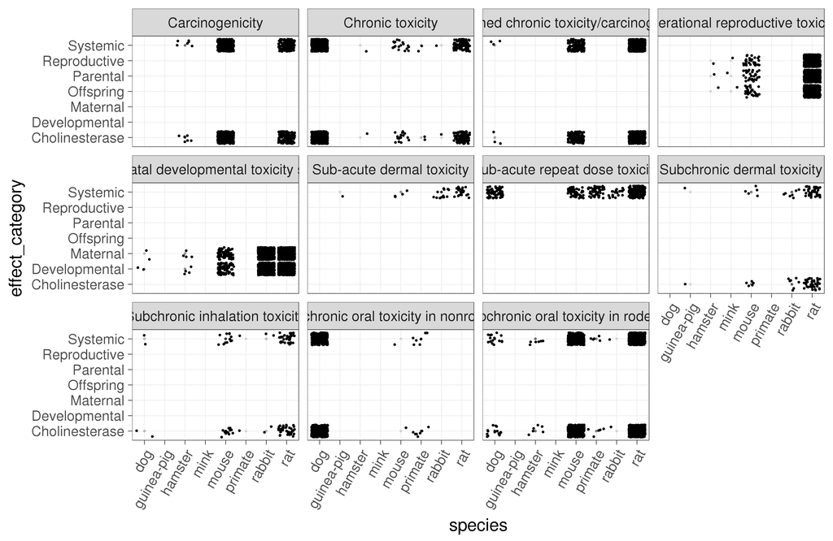

```r
ggplot(data = sample_frac(toxcast, 1), aes(x = species, y = effect_category)) +
  geom_point(alpha = 1/9) +
  geom_jitter(position = "jitter") +
  facet_wrap( ~ guideline_name) +
  theme_bw(base_size = 30) +
  theme(axis.text.x = element_text(angle = 60, hjust = 1))
```

## 1B) Which species is most frequently represented in the data?

Write a number of code lines to determine the number of animals used for the species that is the most frequently represented in the data. Use the variable `species` to substantiate you claim.

**ANSWER**

```r
str(toxcast$species)
```

```
##  chr [1:11815] "dog" "dog" "rat" "rat" "rat" "dog" "dog" "mouse" ...
```

```r
toxcast$species <- as.factor(toxcast$species)

(species <- toxcast %>%
  count(species))
```

```
## # A tibble: 8 × 2
##      species     n
##       <fctr> <int>
## 1        dog  1486
## 2 guinea-pig     3
## 3    hamster    37
## 4       mink     3
## 5      mouse  2102
## 6    primate    77
## 7     rabbit  1346
## 8        rat  6761
```

```r
## or
pander::pander(table(toxcast$species))
```

| dog | guinea-pig | hamster | mink | mouse | primate | rabbit | rat |
| --- | --- | --- | --- | --- | --- | --- | --- |
| 1486 | 3 | 37 | 3 | 2102 | 77 | 1346 | 6761 |

## Graph 2) A categorical and a continuous variable

**Use only the data for the dog in this graph, and only for the chemicals below:**

- “Sulfentrazone”
- “Cyproconazole”
- “Thiamethoxam”
- “Glufosinate-ammonium”
- “Flusilazoleand”